# Week 3 Exercises

# Exercise 3

#### 3.1

Calculate the mean, standard deviation (sd), and number of observations (n) of **score by education and age group**. Also calculate the standard error of the mean (by using sd and n). Save these into a new data frame (or tibble) named edu_age_stats.

```r
edu_age_stats <- df %>%
  group_by(education, age_group) %>%
  summarise(mean_score = mean(score),
            sd_score = sd(score),
            n = n()) %>%
  mutate(se_score = sd_score/sqrt(n)) %>%
  ungroup()
str(edu_age_stats)
```

```
## tibble [15 x 6] (S3: tbl_df/tbl/data.frame)
##  $ education : Factor w/ 3 levels "1","2","3": 1 1 1 1 1 2 2 2 2 2 ...
##  $ age_group : Factor w/ 5 levels "[15,25]","(25,35]",..: 1 2 3 4 5 1 2 3 4 5 ...
##  $ mean_score: num [1:15] 10.09 10.2 10.01 10.41 9.03 ...
##  $ sd_score  : num [1:15] 2.3 2.81 2.86 2.56 5.51 ...
##  $ n         : int [1:15] 12 18 31 20 4 5 15 24 26 7 ...
##  $ se_score  : num [1:15] 0.664 0.663 0.515 0.572 2.755 ...
```

#### 3.2

Using edu_age_stats, plot a bar plot that has **age group** on the x-axis, **mean score** on the y-axis, and **education levels** in subplots (facets).

Use `geom_errorbar()` to add error bars that represent standard errors of the mean.

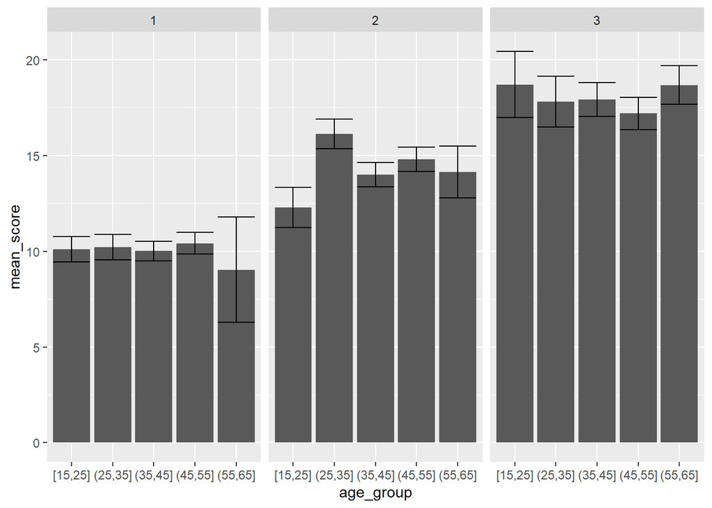

```r
edu_age_stats %>%
  ggplot(aes(age_group, mean_score)) + geom_bar(stat='identity') + facet_wrap(~education) + geom_errorbar(aes(ymin=mean_score-se_score, ymax=mean_score+se_score))
```

# Exercise 4

#### 4.1

Create a figure that has boxplots of **score** (x-axis) by **region** (y-axis).

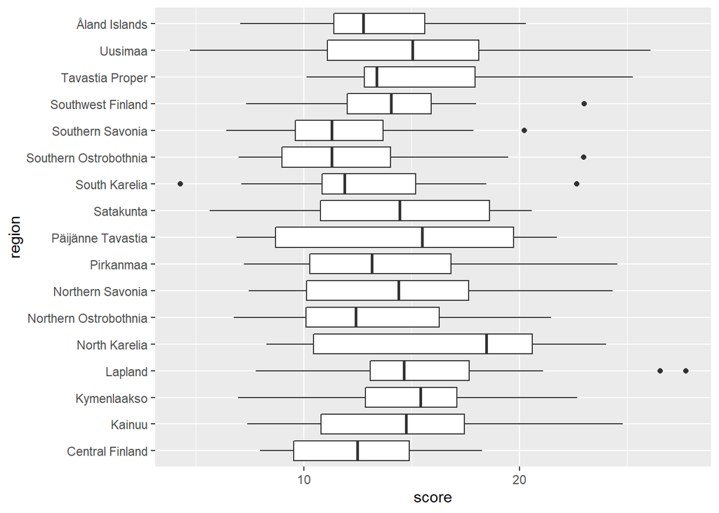

```r
df %>%
  ggplot(aes(score, region)) + geom_boxplot()
```

#### 4.2

Group the data by region and add mean score by region to a new column **mean_score**. Do this with **`mutate()`** (not `summarise()`).

Reorder the levels of region based on mean_score.

**Hint**: Remember to ungroup after creating the mean_score variable.

```r
df_grp <- df %>%
  group_by(region) %>%
  mutate(mean_score=mean(score)) %>%
  ungroup()
str(df_grp)
```

```
## tibble [240 x 8] (S3: tbl_df/tbl/data.frame)
##  $ id        : num [1:240] 1 2 3 4 5 6 7 8 9 10 ...
##  $ region    : chr [1:240] "South Karelia" "Satakunta" "Kymenlaakso" "South Karelia" ...
##  $ education : Factor w/ 3 levels "1","2","3": 1 1 1 1 1 1 1 1 1 1 ...
##  $ gender    : chr [1:240] "M" "F" "M" "F" ...
##  $ age       : num [1:240] 56 41 48 41 35 60 28 28 48 51 ...
##  $ score     : num [1:240] 4.27 5.65 6.95 7.1 6.99 ...
##  $ age_group : Factor w/ 5 levels "[15,25]","(25,35]",..: 5 3 4 3 2 5 2 2 4 4 ...
##  $ mean_score: num [1:240] 13 14.2 14.9 13 12.4 ...
```

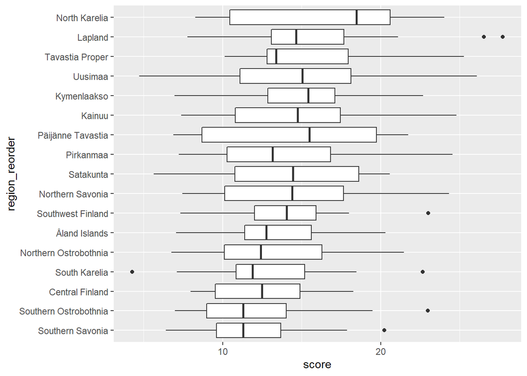

```r
df_grp %>%
  mutate(region_reorder = fct_reorder(region, mean_score)) %>%
  ggplot(aes(score, region_reorder)) + geom_boxplot()
```

# Exercise 5

Using the data you modified in exercise 4.2, plot **mean scores** (x-axis) by **region** (y-axis) as points. The regions should be ordered by mean score.

Use `stat_summary()` to add error bars that represent standard errors of the mean.

**Hint**: Be careful which variable - mean_score or score - you’re plotting in each of the geoms.

```r
str(df_grp)
```

```
## tibble [240 x 8] (S3: tbl_df/tbl/data.frame)
##  $ id        : num [1:240] 1 2 3 4 5 6 7 8 9 10 ...
##  $ region    : chr [1:240] "South Karelia" "Satakunta" "Kymenlaakso" "South Karelia" ...
##  $ education : Factor w/ 3 levels "1","2","3": 1 1 1 1 1 1 1 1 1 1 ...
##  $ gender    : chr [1:240] "M" "F" "M" "F" ...
##  $ age       : num [1:240] 56 41 48 41 35 60 28 28 48 51 ...
##  $ score     : num [1:240] 4.27 5.65 6.95 7.1 6.99 ...
##  $ age_group : Factor w/ 5 levels "[15,25]","(25,35]",..: 5 3 4 3 2 5 2 2 4 4 ...
##  $ mean_score: num [1:240] 13 14.2 14.9 13 12.4 ...
```

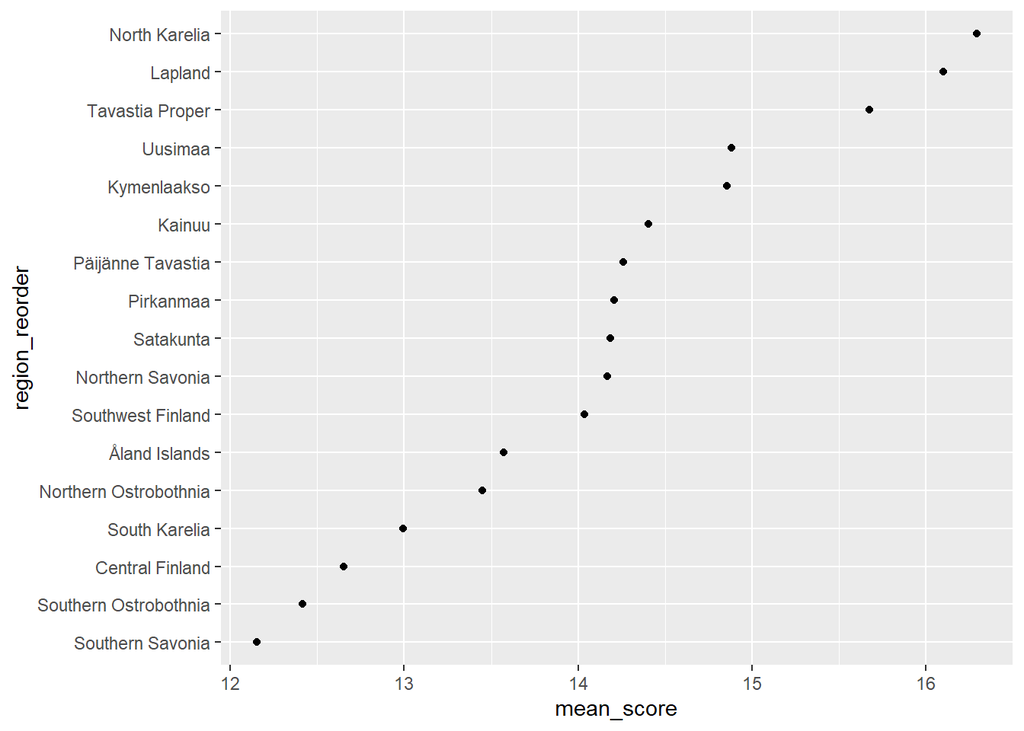

```r
df_grp %>%
  mutate(region_reorder = fct_reorder(region, mean_score)) %>%
  ggplot(aes(mean_score, region_reorder)) + stat_summary(geom = "point", fun.data = "mean_se") + stat_summary(geom = "linerange", fun.data = "mean_se")
```

```r
## Using **mean_score**, there is no variation as there is a single score for each region. Using **score** we would get error bars.
```